# SAVI case study — STING signature on monocytic reference

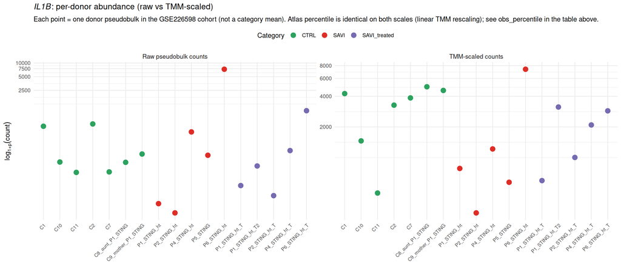

```r
il1b_counts_long <- il1b_sample_tbl |>
  dplyr::mutate(
    sample_label = factor(
      Sample,
      levels = il1b_sample_tbl |>
        dplyr::arrange(Category, Sample) |>
        dplyr::pull(Sample) |>
        unique()
    )
  ) |>
  tidyr::pivot_longer(
    cols = c("observed_count", "observed_scaled"),
    names_to = "measure",
    values_to = "abundance"
  ) |>
  dplyr::mutate(
    measure = dplyr::recode(
      .data$measure,
      observed_count = "Raw pseudobulk counts",
      observed_scaled = "TMM-scaled counts"
    ),
    measure = factor(
      .data$measure,
      levels = c("Raw pseudobulk counts", "TMM-scaled counts")
    )
  )

log1p_trans <- scales::trans_new(
  name = "log1p",
  transform = function(x) log1p(pmax(x, 0)),
  inverse = function(x) expm1(x),
  domain = c(0, Inf)
)

ggplot2::ggplot(
  il1b_counts_long,
  ggplot2::aes(
    x = sample_label,
    y = abundance,
    colour = Category
  )
) +
  ggplot2::geom_point(size = 3.5) +
  ggplot2::facet_wrap(~measure, scales = "free_y", ncol = 2) +
  ggplot2::scale_y_continuous(trans = log1p_trans) +
  ggplot2::scale_colour_manual(values = category_cols) +
  ggplot2::labs(
    x = NULL,
    y = expression(log[1 + p]("count")),
    title = expression(italic("IL1B") * ": per-donor abundance (raw vs TMM-scaled)"),
    subtitle = paste0(
      "Each point = one donor pseudobulk in the GSE226598 cohort (not a category mean). ",
      "Atlas percentile is identical on both scales (linear TMM rescaling); ",
      "see obs_percentile in the table above."
    )
  ) +
  ggplot2::theme_minimal(base_size = 11) +
  ggplot2::theme(
    axis.text.x = ggplot2::element_text(angle = 45, hjust = 1, size = 8),
    legend.position = "top",
    strip.text = ggplot2::element_text(size = 10)
  )
```

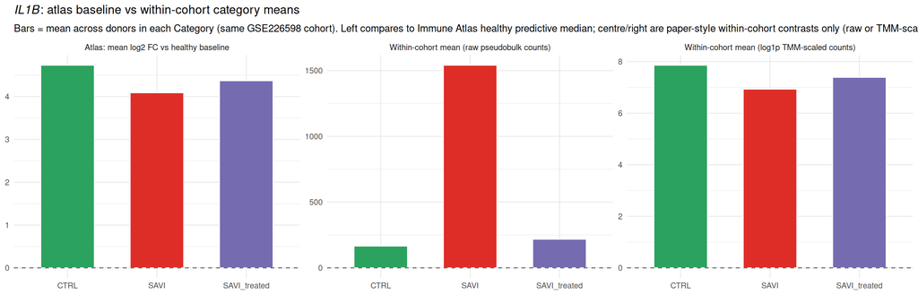

```r
# Three reference frames for IL1B:
#   Atlas  — mean log2(obs / healthy predictive median) across donors in each Category.
#   Paper  — mean abundance within the GSE226598 cohort only (no atlas); bars = cohort mean
#            per Category (CTRL n≈7, SAVI n≈5, SAVI_treated n varies), not individual donors.
paper_null <- il1b_sample_tbl |>
  dplyr::group_by(Category) |>
  dplyr::summarise(
    mean_obs = mean(observed_count),
    mean_scaled = mean(observed_scaled),
    mean_log1p_scaled = mean(log1p(pmax(observed_scaled, 0))),
    .groups = "drop"
  )

atlas_null <- il1b_sample_tbl |>
  dplyr::group_by(Category) |>
  dplyr::summarise(
    mean_log2fc = mean(log2fc_vs_median),
    .groups = "drop"
  )

two_nulls_long <- dplyr::bind_rows(
  atlas_null |>
    dplyr::mutate(
      metric = "Atlas: mean log2 FC vs healthy baseline",
      value = .data$mean_log2fc,
      y_label = "Mean log2(obs / healthy median)"
    ) |>
    dplyr::select("Category", "metric", "value", "y_label"),
  paper_null |>
    dplyr::mutate(
      metric = "Within-cohort mean (raw pseudobulk counts)",
      value = .data$mean_obs,
      y_label = "Mean raw count"
    ) |>
    dplyr::select("Category", "metric", "value", "y_label"),
  paper_null |>
    dplyr::mutate(
      metric = "Within-cohort mean (log1p TMM-scaled counts)",
      value = .data$mean_log1p_scaled,
      y_label = "log1p(mean scaled count)"
    ) |>
    dplyr::select("Category", "metric", "value", "y_label")
) |>
  dplyr::mutate(
    Category = factor(Category, levels = names(category_cols)),
    metric = factor(
      metric,
      levels = c(
        "Atlas: mean log2 FC vs healthy baseline",
        "Within-cohort mean (raw pseudobulk counts)",
        "Within-cohort mean (log1p TMM-scaled counts)"
      )
    )
  )

ggplot2::ggplot(
  two_nulls_long,
  ggplot2::aes(x = Category, y = value, fill = Category)
) +
  ggplot2::geom_col(width = 0.6, colour = "white") +
  ggplot2::geom_hline(yintercept = 0, linetype = 2, colour = "grey40") +
  ggplot2::facet_wrap(~metric, scales = "free_y", ncol = 3) +
  ggplot2::scale_fill_manual(values = category_cols) +
  ggplot2::labs(
    x = NULL,
    y = NULL,
    title = expression(italic("IL1B") * ": atlas baseline vs within-cohort category means"),
    subtitle = paste0(
      "Bars = mean across donors in each Category (same GSE226598 cohort). ",
      "Left compares to Immune Atlas healthy predictive median; centre/right are paper-style ",
      "within-cohort contrasts only (raw or TMM-scaled pseudobulk counts)."
    )
  ) +
  ggplot2::theme_minimal(base_size = 11) +
  ggplot2::theme(
    legend.position = "none",
    strip.text = ggplot2::element_text(size = 9)
  )
```

```r
# Subsampled posterior_predict draws for density overlays (IL1B vs TSC22D2).
# Model scale = raw pseudobulk counts (same as atlas posterior_predict).
predictive_draws_raw_for_gene <- function(
  gene_sym,
  se,
  comparison_tbl,
  sample_ann,
  ndraws = 400L
) {
  chunk_row <- sting_fit_rows |>
    dplyr::filter(.data$gene == .env$gene_sym) |>
    dplyr::slice(1)

  if (!nrow(chunk_row)) {
    stop("No fit found for gene: ", gene_sym)
  }

  fit <- poco::reconstruct_brmsfit(chunk_row$brms_fit_compressed[[1]])
  feature_id <- chunk_row$.feature

  purrr::pmap_dfr(
    comparison_tbl |>
      dplyr::filter(.data$sample_role == "savi_pseudobulk") |>
      dplyr::select("sample", "sample_idx"),
    function(sample, sample_idx) {
      newdata <- newdata_for_sample(se, sample_idx)
      nd_grid <- build_newdata_grid(
        fit,
        newdata,
        new_level_tag = paste0("__savi__", as.character(sample))
      )

      y_rep <- brms::posterior_predict(
        fit,
        newdata = nd_grid,
        summary = FALSE,
        re_formula = NULL,
        allow_new_levels = TRUE,
        sample_new_levels = "uncertainty",
        ndraws = ndraws
      ) |>
        as.numeric()

      obs_raw <- SummarizedExperiment::assay(
        se[feature_id, sample_idx, drop = FALSE],
        "counts"
      ) |>
        as.numeric()

      tibble::tibble(
        gene = gene_sym,
        sample = as.character(sample),
        draw = y_rep,
        observed_count = obs_raw
      )
    }
  ) |>
    dplyr::left_join(
      sample_ann |>
        dplyr::select("sample", "Sample", "Category"),
      by = "sample"
    )
}

contrast_draws <- purrr::map_dfr(
  falsify_contrast_genes,
  predictive_draws_raw_for_gene,
  se = se_monocytic,
  comparison_tbl = comparison_samples_tbl,
  sample_ann = sample_annotations
) |>
  dplyr::mutate(
    Category = factor(.data$Category, levels = names(category_cols)),
    gene = factor(.data$gene, levels = falsify_contrast_genes),
    draw_log1p = log1p(pmax(.data$draw, 0)),
    observed_log1p = log1p(pmax(.data$observed_count, 0))
  )

contrast_draws |>
  dplyr::count(.data$gene, .data$Category, name = "n_draws")
```

| gene | Category | n_draws |
| --- | --- | --- |
| IL1B | CTRL | 19600 |
| IL1B | SAVI | 14000 |
| IL1B | SAVI_treated | 14000 |
| TSC22D2 | CTRL | 19600 |
| TSC22D2 | SAVI | 14000 |
| TSC22D2 | SAVI_treated | 14000 |

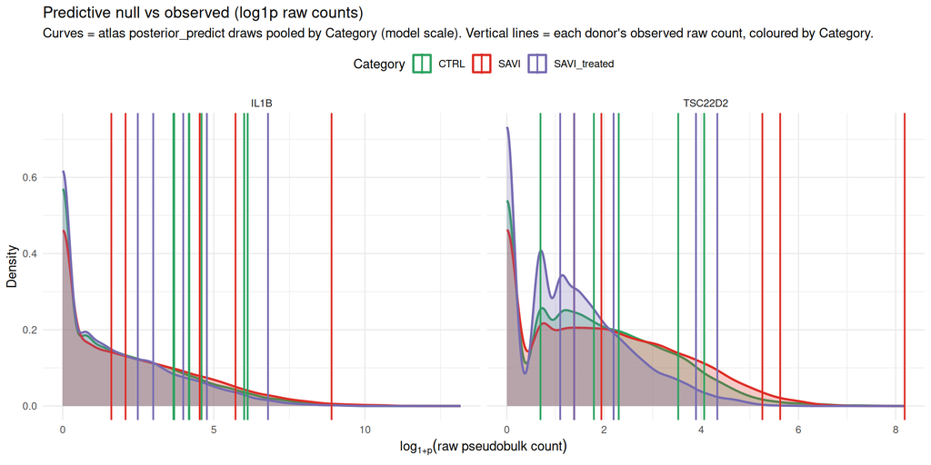

```r
ggplot2::ggplot(
  contrast_draws,
  ggplot2::aes(x = draw_log1p, colour = Category, fill = Category)
) +
  ggplot2::geom_density(alpha = 0.25, linewidth = 0.9) +
  ggplot2::geom_vline(
    data = contrast_draws |>
      dplyr::distinct(.data$gene, .data$sample, .data$Category, .data$observed_log1p),
    ggplot2::aes(
      xintercept = observed_log1p,
      colour = Category
    ),
    linetype = "solid",
    linewidth = 0.7
  ) +
  ggplot2::facet_wrap(~gene, scales = "free_x") +
  ggplot2::scale_colour_manual(values = category_cols, name = "Category") +
  ggplot2::scale_fill_manual(values = category_cols, guide = "none") +
  ggplot2::labs(
    x = expression(log[1 + p]("raw pseudobulk count")),
    y = "Density",
    title = "Predictive null vs observed (log1p raw counts)",
    subtitle = paste(
      "Curves = atlas posterior_predict draws pooled by Category (model scale).",
      "Vertical lines = each donor's observed raw count, coloured by Category."
    )
  ) +
  ggplot2::theme_minimal(base_size = 11) +
  ggplot2::theme(legend.position = "top")
```

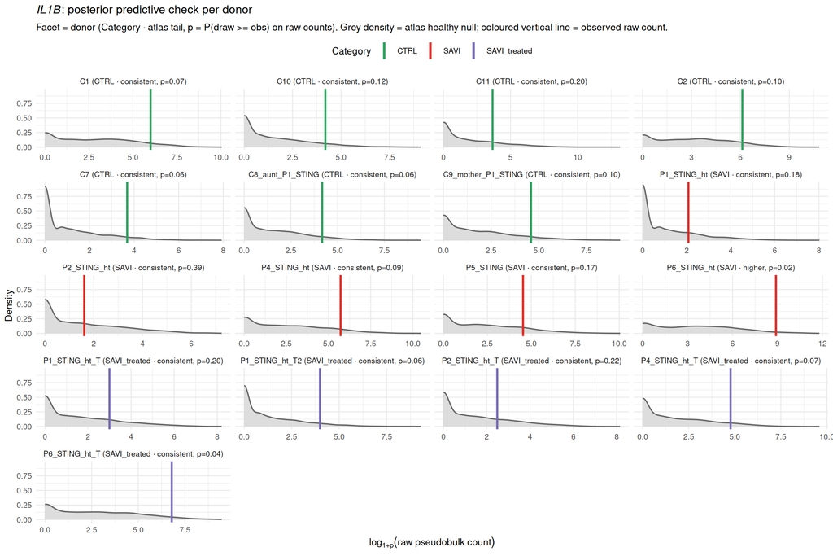

```r
il1b_facet_lookup <- il1b_sample_tbl |>
  dplyr::select(dplyr::any_of(c(
    "sample",
    "Sample",
    "Category",
    "direction",
    "p_above_healthy"
  ))) |>
  dplyr::mutate(
    direction_short = dplyr::case_when(
      .data$direction == "higher_than_healthy" ~ "higher",
      .data$direction == "lower_than_healthy" ~ "lower",
      TRUE ~ "consistent"
    ),
    sample_label = paste0(
      .data$Sample,
      " (",
      .data$Category,
      " · ",
      .data$direction_short,
      ", p=",
      sprintf("%.2f", .data$p_above_healthy),
      ")"
    )
  )

il1b_label_levels <- il1b_facet_lookup |>
  dplyr::arrange(.data$Category, .data$Sample)

il1b_facet_lookup <- il1b_facet_lookup |>
  dplyr::mutate(
    sample_label = factor(
      .data$sample_label,
      levels = il1b_label_levels$sample_label
    )
  )

il1b_draws <- contrast_draws |>
  dplyr::filter(.data$gene == "IL1B") |>
  dplyr::left_join(
    il1b_facet_lookup |>
      dplyr::select(.data$sample, .data$sample_label),
    by = "sample"
  )

ggplot2::ggplot(
  il1b_draws,
  ggplot2::aes(x = draw_log1p, colour = Category)
) +
  ggplot2::geom_density(fill = "grey85", colour = "grey40", linewidth = 0.6, alpha = 0.9) +
  ggplot2::geom_vline(
    ggplot2::aes(xintercept = observed_log1p, colour = Category),
    linewidth = 1
  ) +
  ggplot2::facet_wrap(~sample_label, scales = "free_x", ncol = 4) +
  ggplot2::scale_colour_manual(values = category_cols, name = "Category") +
  ggplot2::guides(colour = ggplot2::guide_legend(override.aes = list(linewidth = 1.2))) +
  ggplot2::labs(
    x = expression(log[1 + p]("raw pseudobulk count")),
    y = "Density",
    title = expression(italic("IL1B") * ": posterior predictive check per donor"),
    subtitle = paste(
      "Facet = donor (Category · atlas tail, p = P(draw >= obs) on raw counts).",
      "Grey density = atlas healthy null; coloured vertical line = observed raw count."
    )
  ) +
  ggplot2::theme_minimal(base_size = 10) +
  ggplot2::theme(
    legend.position = "top",
    strip.text = ggplot2::element_text(size = 8)
  )
```

```r
il1b_ctrl_vs_savi <- il1b_sample_tbl |>
  dplyr::group_by(.data$Category) |>
  dplyr::summarise(
    n = dplyr::n(),
    mean_obs = mean(.data$observed_count),
    mean_log2fc = mean(.data$log2fc_vs_median),
    pct_above_hpd = 100 * mean(.data$above_hpd),
    pct_higher_direction = 100 * mean(.data$direction == "higher_than_healthy"),
    mean_percentile = 100 * mean(.data$obs_percentile),
    .groups = "drop"
  )

ctrl_mean_log2fc <- il1b_ctrl_vs_savi |>
  dplyr::filter(.data$Category == "CTRL") |>
  dplyr::pull(.data$mean_log2fc)

ctrl_pct_above_hpd <- il1b_ctrl_vs_savi |>
  dplyr::filter(.data$Category == "CTRL") |>
  dplyr::pull(.data$pct_above_hpd)

savi_pct_above_hpd <- il1b_ctrl_vs_savi |>
  dplyr::filter(.data$Category == "SAVI") |>
  dplyr::pull(.data$pct_above_hpd)

paper_delta <- il1b_ctrl_vs_savi |>
  dplyr::filter(.data$Category %in% c("SAVI", "CTRL")) |>
  tidyr::pivot_wider(names_from = "Category", values_from = "mean_obs") |>
  dplyr::mutate(delta = .data$SAVI - .data$CTRL) |>
  dplyr::pull(.data$delta)

atlas_delta <- biomarker_quality |>
  dplyr::filter(.data$gene == "IL1B") |>
  dplyr::pull(.data$savi_vs_ctrl)

tibble::tibble(
  gene = "IL1B",
  paper_mean_savi_minus_ctrl_raw_counts = paper_delta,
  atlas_mean_log2fc_savi_minus_ctrl = atlas_delta,
  ctrl_pct_above_healthy_hpd = ctrl_pct_above_hpd,
  savi_pct_above_healthy_hpd = savi_pct_above_hpd,
  falsification_verdict = dplyr::if_else(
    is.finite(atlas_delta) &&
      atlas_delta < 0 &&
      is.finite(ctrl_mean_log2fc) &&
      ctrl_mean_log2fc > 0,
    "Atlas falsified: controls high, SAVI not elevated after correction",
    "Review manually"
  )
)
```

| gene | paper_mean_savi_minus_ctrl_raw_counts | atlas_mean_log2fc_savi_minus_ctrl | ctrl_pct_above_healthy_hpd | savi_pct_above_healthy_hpd | falsification_verdict |
| --- | --- | --- | --- | --- | --- |
| IL1B | NA | -0.6430628 | 0 | 20 | Atlas falsified: controls high, SAVI not elevated after correction |
| IL1B | NA | -0.6430628 | 0 | 20 | Atlas falsified: controls high, SAVI not elevated after correction |

```r
il1b_ctrl_vs_savi
```

| Category | n | mean_obs | mean_log2fc | pct_above_hpd | pct_higher_direction | mean_percentile |
| --- | --- | --- | --- | --- | --- | --- |
| CTRL | 7 | 166.0 | 4.733310 | 0 | 0 | 89.98980 |
| SAVI | 5 | 1541.4 | 4.090247 | 20 | 20 | 83.62143 |
| SAVI_treated | 5 | 218.0 | 4.370370 | 20 | 0 | 88.51429 |

# Case study: falsifying *ADRB2* (one-donor SAVI signal)

**ADRB2** is labelled **`falsified_no_savi_signal`** in the biomarker screen because only **20%** of SAVI donors pass the strict atlas tail call (`higher_than_healthy`), yet the **cohort mean** `log2fc_vs_median` in SAVI looks high. That pattern usually means **one outlier donor** pulls the category mean while the other SAVI pseudobulks sit near the healthy predictive null.

We audit that claim with per-donor tables, leave-one-out SAVI means, and density overlays on **raw pseudobulk counts** (same scale as `posterior_predict`; contrast gene **TSC22D2** = validated atlas behaviour).

```r
adrb2_ensembl <- sting_signature_21 |>
  dplyr::filter(.data$gene == "ADRB2") |>
  dplyr::pull(.feature)

adrb2_scaled_obs <- tibble::tibble(sample = colnames(se_monocytic)) |>
  dplyr::mutate(
    sample_idx = match(.data$sample, colnames(se_monocytic)),
    observed_scaled = as.numeric(
      SummarizedExperiment::assay(
        se_monocytic[adrb2_ensembl, .data$sample_idx, drop = FALSE],
        scaled_counts_assay_name(se_monocytic)
      )
    )
  )

adrb2_sample_tbl <- gene_deviation_eval |>
  dplyr::filter(.data$gene == "ADRB2", !is.na(.data$Category)) |>
  dplyr::left_join(
    sample_annotations |>
      dplyr::select("sample", tidyselect::any_of("Treatment")),
    by = "sample"
  ) |>
  dplyr::left_join(adrb2_scaled_obs, by = "sample") |>
  dplyr::mutate(
    Category = factor(.data$Category, levels = names(category_cols)),
    scale_ratio = .data$observed_scaled / pmax(.data$observed_count, 1e-9),
    healthy_median_scaled = .data$healthy_median * .data$scale_ratio,
    healthy_hpd_lo_scaled = .data$healthy_hpd_lo * .data$scale_ratio,
    healthy_hpd_hi_scaled = .data$healthy_hpd_hi * .data$scale_ratio,
    above_hpd = .data$observed_count > .data$healthy_hpd_hi,
    below_hpd = .data$observed_count < .data$healthy_hpd_lo,
    in_hpd = !.data$above_hpd & !.data$below_hpd
  ) |>
  dplyr::arrange(.data$Category, .data$Sample)

adrb2_savi_tbl <- adrb2_sample_tbl |>
  dplyr::filter(.data$Category == "SAVI")

adrb2_savi_outlier_pick <- adrb2_savi_tbl |>
  dplyr::filter(.data$direction == "higher_than_healthy") |>
  dplyr::slice(1)

if (nrow(adrb2_savi_outlier_pick) == 0L) {
  adrb2_savi_outlier_pick <- adrb2_savi_tbl |>
    dplyr::slice_max(.data$log2fc_vs_median, n = 1, with_ties = FALSE)
}

adrb2_label_levels <- adrb2_sample_tbl |>
  dplyr::arrange(.data$Category, .data$Sample)

adrb2_sample_tbl <- adrb2_sample_tbl |>
  dplyr::mutate(
    savi_outlier = .data$sample %in% adrb2_savi_outlier_pick$sample,
    direction_short = dplyr::case_when(
      .data$direction == "higher_than_healthy" ~ "higher",
      .data$direction == "lower_than_healthy" ~ "lower",
      TRUE ~ "consistent"
    ),
    sample_facet_label = paste0(
      .data$Sample,
      " (",
      .data$Category,
      " · ",
      .data$direction_short,
      ", p=",
      sprintf("%.2f", .data$p_above_healthy),
      ")"
    ),
    sample_label = factor(
      .data$sample_facet_label,
      levels = adrb2_label_levels |>
        dplyr::mutate(
          lab = paste0(
            .data$Sample,
            " (",
            .data$Category,
            " · ",
            dplyr::case_when(
              .data$direction == "higher_than_healthy" ~ "higher",
              .data$direction == "lower_than_healthy" ~ "lower",
              TRUE ~ "consistent"
            ),
            ", p=",
            sprintf("%.2f", .data$p_above_healthy),
            ")"
          )
        ) |>
        dplyr::pull(.data$lab)
    )
  )

adrb2_savi_outlier <- adrb2_sample_tbl |>
  dplyr::filter(.data$savi_outlier)

adrb2_loo_summary <- tibble::tibble(
  contrast = c(
    "All SAVI donors",
    "Drop atlas-tail SAVI donor",
    "Other SAVI donors (median)"
  ),
  n_savi = c(
    nrow(adrb2_savi_tbl),
    nrow(adrb2_savi_tbl) - 1L,
    nrow(adrb2_savi_tbl) - 1L
  ),
  mean_log2fc = c(
    mean(adrb2_savi_tbl$log2fc_vs_median),
    mean(
      adrb2_savi_tbl$log2fc_vs_median[
        adrb2_savi_tbl$sample != adrb2_savi_outlier$sample
      ]
    ),
    stats::median(
      adrb2_savi_tbl$log2fc_vs_median[
        adrb2_savi_tbl$sample != adrb2_savi_outlier$sample
      ]
    )
  ),
  pct_higher = c(
    100 * mean(adrb2_savi_tbl$direction == "higher_than_healthy"),
    100 * mean(
      adrb2_savi_tbl$direction[
        adrb2_savi_tbl$sample != adrb2_savi_outlier$sample
      ] == "higher_than_healthy"
    ),
    NA_real_
  )
)

adrb2_per_donor <- adrb2_sample_tbl |>
  dplyr::select(
    Sample,
    Category,
    direction,
    direction_short,
    p_above_healthy,
    log2fc_vs_median,
    obs_percentile,
    observed_count,
    observed_scaled,
    savi_outlier,
    sample_facet_label
  )

adrb2_per_donor
```

| Sample | Category | direction | direction_short | p_above_healthy | log2fc_vs_median | obs_percentile | observed_count | observed_scaled | savi_outlier | sample_facet_label |
| --- | --- | --- | --- | --- | --- | --- | --- | --- | --- | --- |
| C1 | CTRL | consistent_with_healthy | consistent | 0.528571429 | 0.0000000 | 0.5082143 | 4 | 42.10146 | FALSE | C1 (CTRL · consistent, p=0.53) |
| C10 | CTRL | consistent_with_healthy | consistent | 1.000000000 | -1.0000000 | 0.4303571 | 0 | 0.00000 | FALSE | C10 (CTRL · consistent, p=1.00) |
| C11 | CTRL | consistent_with_healthy | consistent | 1.000000000 | 0.0000000 | 0.5439286 | 0 | 0.00000 | FALSE | C11 (CTRL · consistent, p=1.00) |
| C2 | CTRL | consistent_with_healthy | consistent | 0.408214286 | 0.7369656 | 0.6157143 | 9 | 64.88019 | FALSE | C2 (CTRL · consistent, p=0.41) |
| C7 | CTRL | consistent_with_healthy | consistent | 1.000000000 | 0.0000000 | 0.5828571 | 0 | 0.00000 | FALSE | C7 (CTRL · consistent, p=1.00) |
| C8_aunt_P1_STING | CTRL | consistent_with_healthy | consistent | 1.000000000 | 0.0000000 | 0.5900000 | 0 | 0.00000 | FALSE | C8_aunt_P1_STING (CTRL · consistent, p=1.00) |
| C9_mother_P1_STING | CTRL | consistent_with_healthy | consistent | 1.000000000 | 0.0000000 | 0.5064286 | 0 | 0.00000 | FALSE | C9_mother_P1_STING (CTRL · consistent, p=1.00) |
| P1_STING_ht | SAVI | consistent_with_healthy | consistent | 0.374642857 | 1.0000000 | 0.7825000 | 1 | 111.38929 | FALSE | P1_STING_ht (SAVI · consistent, p=0.37) |
| P2_STING_ht | SAVI | consistent_with_healthy | consistent | 1.000000000 | 0.0000000 | 0.5075000 | 0 | 0.00000 | FALSE | P2_STING_ht (SAVI · consistent, p=1.00) |
| P4_STING_ht | SAVI | consistent_with_healthy | consistent | 0.128214286 | 2.8744691 | 0.8750000 | 65 | 260.29351 | FALSE | P4_STING_ht (SAVI · consistent, p=0.13) |

[output cut: 7 more lines]

```r
adrb2_loo_summary
```

| contrast | n_savi | mean_log2fc | pct_higher |
| --- | --- | --- | --- |
| All SAVI donors | 5 | 2.583983 | 20 |
| Drop atlas-tail SAVI donor | 4 | 1.483341 | 0 |
| Other SAVI donors (median) | 4 | 1.529447 | NA |

```r
tibble::tibble(
  outlier_sample = adrb2_savi_outlier$Sample,
  outlier_direction = adrb2_savi_outlier$direction,
  outlier_log2fc = adrb2_savi_outlier$log2fc_vs_median,
  n_savi_higher_than_healthy = sum(adrb2_savi_tbl$direction == "higher_than_healthy"),
  n_savi_consistent = sum(adrb2_savi_tbl$direction == "consistent_with_healthy"),
  biomarker_class = biomarker_quality |>
    dplyr::filter(.data$gene == "ADRB2") |>
    dplyr::pull(.data$biomarker_class)
)
```

| outlier_sample | outlier_direction | outlier_log2fc | n_savi_higher_than_healthy | n_savi_consistent | biomarker_class |
| --- | --- | --- | --- | --- | --- |
| P6_STING_ht | higher_than_healthy | 6.986553 | 1 | 4 | falsified_no_savi_signal |

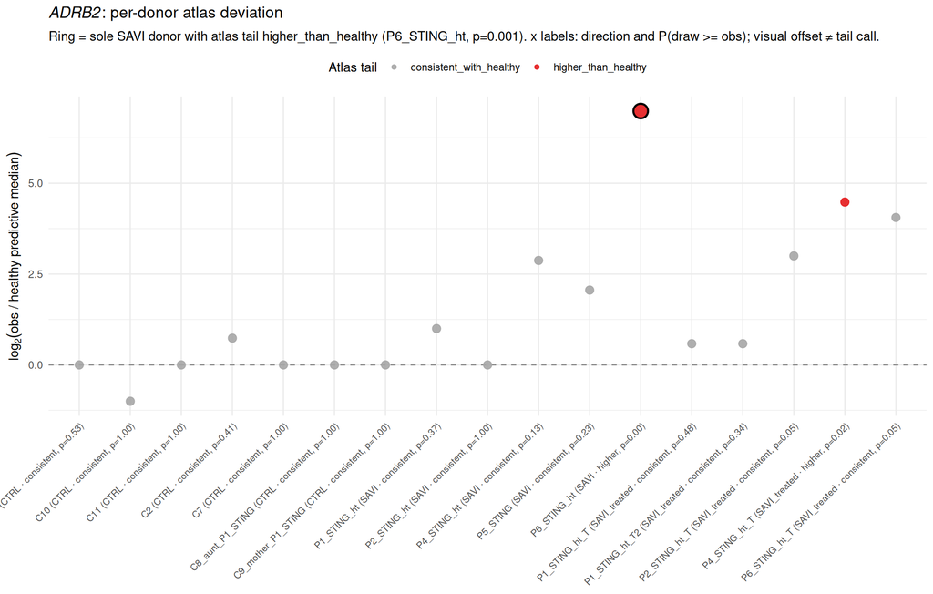

```r
direction_cols <- c(
  higher_than_healthy = "#E41A1C",
  lower_than_healthy = "#377EB8",
  consistent_with_healthy = "grey65"
)

ggplot2::ggplot(
  adrb2_sample_tbl,
  ggplot2::aes(
    x = sample_label,
    y = log2fc_vs_median,
    colour = direction
  )
) +
  ggplot2::geom_hline(yintercept = 0, linetype = 2, colour = "grey55") +
  ggplot2::geom_point(
    ggplot2::aes(size = savi_outlier),
    alpha = 0.9
  ) +
  ggplot2::geom_point(
    data = adrb2_savi_outlier,
    ggplot2::aes(x = sample_label, y = log2fc_vs_median),
    shape = 21,
    fill = NA,
    colour = "black",
    stroke = 1.2,
    size = 5,
    inherit.aes = FALSE
  ) +
  ggplot2::scale_colour_manual(values = direction_cols, name = "Atlas tail") +
  ggplot2::scale_size_manual(
    values = c(`TRUE` = 5, `FALSE` = 3),
    guide = "none"
  ) +
  ggplot2::labs(
    x = NULL,
    y = expression(log[2]("obs / healthy predictive median")),
    title = expression(italic("ADRB2") * ": per-donor atlas deviation"),
    subtitle = paste(
      "Ring = sole SAVI donor with atlas tail higher_than_healthy",
      paste0("(", adrb2_savi_outlier$Sample, ", p=", sprintf("%.3f", adrb2_savi_outlier$p_above_healthy), ")."),
      "x labels: direction and P(draw >= obs); visual offset ≠ tail call."
    )
  ) +
  ggplot2::theme_minimal(base_size = 11) +
  ggplot2::theme(
    axis.text.x = ggplot2::element_text(angle = 45, hjust = 1, size = 8),
    legend.position = "top"
  )
```